# Flux Balance Analysis for Metabolic Modeling: A Beginner’s Tutorial

Flux balance analysis (FBA) is a mathematical technique that predicts how metabolites flow through biochemical reactions of a given metabolic network under steady-state conditions. It is widely used in the field of metabolic engineering, as it enables the prediction of phenotypes such as cellular growth rates or the production yields of specific metabolites of interest.

In this tutorial, we begin with a brief explanation of the fundamentals of FBA. We then introduce how to use COBRApy to study the metabolic impacts of genetic modifications.

## What is a metabolic network?

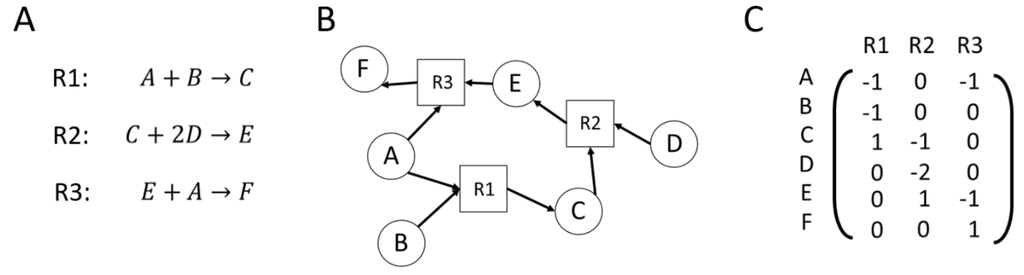

**Figure 1: Representation of metabolic networks.** Networks of biochemical reactions can be represented as (A) equations where the left-hand side represents the metabolites that are consumed and the right-hand side, metabolites that are produced, (B) graphs where metabolites are represented as circles and reactions as boxes, or (C) numerical matrix where columns corresponds to reactions, rows corresponds to metabolites and numbers corresponds to stoichiometric coefficients, with negative and positive coefficients corresponding to consumption and production, respectively, while the value of the coefficient indicates the stoichiometry.

## FBA requires the definition of constraints

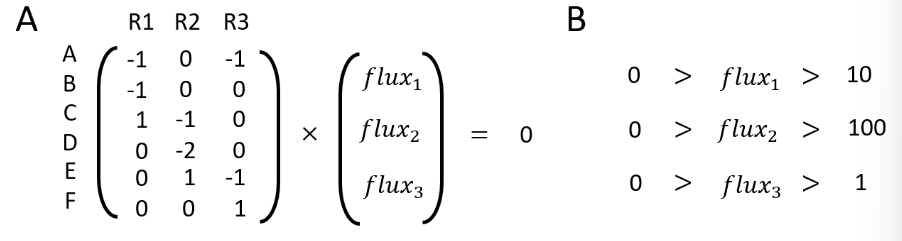

**Figure 2: Mathematical representation of the constraints required for FBA.** In order to analyse the distribution of flux across reactions of a metabolic network, FBA requires to subject the network to two types of constraints. (A) The steady-state constraint requires that the net production and consumption of each metabolite be equal to zero, meaning that each metabolite is consumed at the same rate it is produced across the entire metabolic network. The existence of the mass-balance defines a set of linear equations that can be solved by FBA. (B) The constraint on flux bounds specifies that each reaction flux must lie within a defined lower and upper bound, representing physiological limits.

## The objective function as the representation of the phenotype of interest

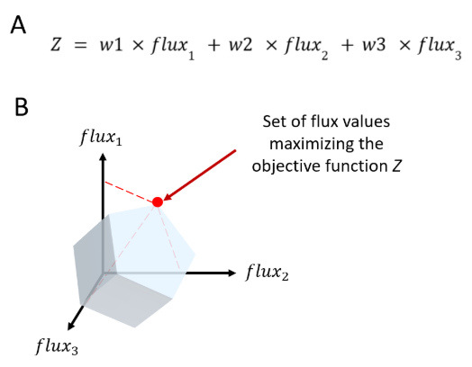

**Figure 3: Identification of optimal reaction fluxes under biochemical constraints.** (A) Mathematical representation of an objective function for an example metabolic network consisting of three reactions. Each reaction is assigned a weight (w) to reflect its relative contribution to the phenotype of interest being optimized. (B) Graphical illustration of the feasible flux space (blue) defined by the constraints, and the optimal flux set (red) in a scenario where the objective is to maximize the flux through Reaction 1.

## Importing required library

The following code snippet loads essential components from the COBRApy package, extensively used in metabolic modeling. Run the following cell to load the required COBRApy modules. This step is necessary before you can execute any of the code below.

```python
import cobra
from cobra.io import load_model
from cobra.util.solver import linear_reaction_coefficients
from cobra import Model, Reaction, Metabolite
from cobra.flux_analysis import find_blocked_reactions, flux_variability_analysis
from cobra.flux_analysis import single_reaction_deletion
from cobra.flux_analysis import single_gene_deletion
import matplotlib.pyplot as plt
import pandas as pd
import numpy as np
from cobra.io import write_sbml_model
```

## Accessing metabolic models

The first step is to retrieve the SBML file of the metabolic model. Here we load the genome scale metabolic network of the strain from the COBRApy's built-in library. Here, we loaded the metabolic model iJB785 of the strain *S.elongatus* PCC 7942 (Broddrick et al, in 2016).

```python
model_PCC7942 = load_model("iJB785")
```

We can first inspect this model. Let's print the number of reactions, metabolites and genes defined in this model.

```python
print(f'There are {len(model_PCC7942.reactions)} reactions in the genome scale metabolic model.')
print(f'There are {len(model_PCC7942.metabolites)} metabolites in the genome scale metabolic model.')
print(f'There are {len(model_PCC7942.genes)} genes in the genome scale metabolic model.')
```

```
There are 849 reactions in the genome scale metabolic model.
There are 768 metabolites in the genome scale metabolic model.
There are 785 genes in the genome scale metabolic model.
```

We can also visualize that the default objective function encoded in the model is the biomass production. This is shown by the coefficient for this reaction set to 1 while all others are set to 0. This can of course be change if we want to maximize something else than the growth of the strain.

```python
linear_reaction_coefficients(model_PCC7942)
```

```
{<Reaction BIOMASS__1 at 0x2873c3bf890>: 1.0}
```

The biomass reaction is one of the most critical reactions in genome-scale metabolic models as it represents the overall process of cellular growth. It does not actually corresponds to a biochemical reaction happening in the cell. Rather, it summarizes all the reactions that contribute to the production of biomass components necessary for growth, such as proteins, lipids, nucleotides, and other macromolecules, as well as the steochiometry of each of these components. We can have a closer look at this reaction.

```python
model_PCC7942.reactions.get_by_id('BIOMASS__1')
```

| **Reaction identifier** | BIOMASS__1 |
| --- | --- |
| **Name** | Biomass objective function |
| **Memory address** | 0x2872ec02330 |
| **Stoichiometry** | 30.0 atp_c + 0.0977 bm_carbs_c + 0.00119 bm_cofactors_c + 0.0795 bm_cw_c + 0.0073 bm_dna_c + 0.159 bm_memlip_c + 0.0197 bm_pigm_c + 0.5112 bm_pro_c + 0.1136 bm_rna_c + 30.0 h2o_c --> 30.0 adp_c +... 3… |
| **GPR** |  |
| **Lower bound** | 0.0 |
| **Upper bound** | 2.0 |

## Running FBA

Before making any addition or deletion in the model, we can perform the FBA with the growth as an objective function, to see what the maximum biomass production of the strain in its current state.

```python
solution_FBA_WT = model_PCC7942.optimize()
print(f"Biomass production: {solution_FBA_WT.objective_value:.5f}")
```

```
Biomass production: 0.05390
```

The summary() function allows us to access the flux of each metabolites that are uptaken and secreted.

```python
model_PCC7942.summary()
```

Objective

1.0 BIOMASS__1 = 0.053902514144384656

Uptake

| Metabolite | Reaction | Flux | C-Number | C-Flux |
| --- | --- | --- | --- | --- |
| co2_e | EX_co2_e | 1.331 | 1 | 56.79% |
| fe3_e | EX_fe3_e | 8.635E-05 | 0 | 0.00% |
| h2o_e | EX_h2o_e | 0.6123 | 0 | 0.00% |
| h_e | EX_h_e | 1.27 | 0 | 0.00% |
| hco3_e | EX_hco3_e | 0.8429 | 1 | 35.95% |
| leu__L_e | EX_leu__L_e | 0.02837 | 6 | 7.26% |
| mg2_e | EX_mg2_e | 0.0006043 | 0 | 0.00% |
| nh4_e | EX_nh4_e | 0.0031 | 0 | 0.00% |
| no3_e | EX_no3_e | 0.4029 | 0 | 0.00% |
| photon430_e | EX_photon430_e | 0.0006043 | 0 | 0.00% |
| photon650_e | EX_photon650_e | 11.7 | 0 | 0.00% |
| photon690_e | EX_photon690_e | 18.2 | 0 | 0.00% |
| pi_e | EX_pi_e | 0.023 | 0 | 0.00% |
| so4_e | EX_so4_e | 0.008394 | 0 | 0.00% |
| amylose_c | SK_amylose_c | 0.02769 | 0 | 0.00% |

Secretion

| Metabolite | Reaction | Flux | C-Number | C-Flux |
| --- | --- | --- | --- | --- |
| 5drib_c | DM_5drib_c | -5.6E-06 | 5 | 26.10% |
| amob_c | DM_amob_c | -1.411E-06 | 15 | 19.73% |
| co_c | DM_co_c | -5.701E-05 | 1 | 53.14% |
| dialurate_c | DM_dialurate_c | -2.758E-07 | 4 | 1.03% |
| pho_loss_c | DM_pho_loss_c | -0.5849 | 0 | 0.00% |
| o2_e | EX_o2_e | -3.151 | 0 | 0.00% |

We can then focus on one metabolite of interest and see which are the reactions producting and consuming it. For example, here are the reaction producing and consuming pyruvate, as well as the flux through these reactions.

```python
model_PCC7942.metabolites.pyr_c.summary()
```

pyr_c

C3H3O3

Producing Reactions

| Percent | Flux | Reaction | Definition |
| --- | --- | --- | --- |
| 0.00% | 4.112E-06 | ADCL | 4adcho_c --> 4abz_c + h_c + pyr_c |
| 0.99% | 0.003852 | ANS2 | chor_c + nh4_c --> anth_c + h2o_c + h_c + pyr_c |
| 0.00% | 9.621E-07 | CHRPL | chor_c --> 4hbz_c + pyr_c |
| 8.20% | 0.03202 | ME2 | mal__L_c + nadp_c <=> co2_c + nadph_c + pyr_c |
| 19.86% | 0.07754 | PYK | adp_c + h_c + pep_c --> atp_c + pyr_c |
| 0.00% | 1.084E-06 | SHCHCS3 | 2sephchc_c --> 2shchc_c + pyr_c |
| 70.95% | 0.277 | VPAMTr | 3mob_c + ala__L_c --> pyr_c + val__L_c |

Consuming Reactions

| Percent | Flux | Reaction | Definition |
| --- | --- | --- | --- |
| 8.29% | -0.03237 | ACLSa | h_c + pyr_c + thmpp_c --> 2ahethmpp_c + co2_c |
| 4.29% | -0.01676 | ACLSb | 2ahethmpp_c + pyr_c --> alac__S_c + thmpp_c |
| 78.26% | -0.3055 | ALAD_L | ala__L_c + h2o_c + nad_c <=> h_c + nadh_c + nh4_c + pyr_c |
| 4.00% | -0.01561 | CITMS | accoa_c + h2o_c + pyr_c --> citm_c + coa_c + h_c |
| 1.86% | -0.007277 | DXPS | g3p_c + h_c + pyr_c --> co2_c + dxyl5p_c |
| 3.30% | -0.01288 | H4THDPS | aspsa_c + pyr_c --> 4hthdp_c + h2o_c + h_c |

## Implementing metabolic modifications

In the following example, we will focus on implementing one reaction deletion and one reaction addition. Figure 4 summarizes how additions and deletions can be represented mathematically.

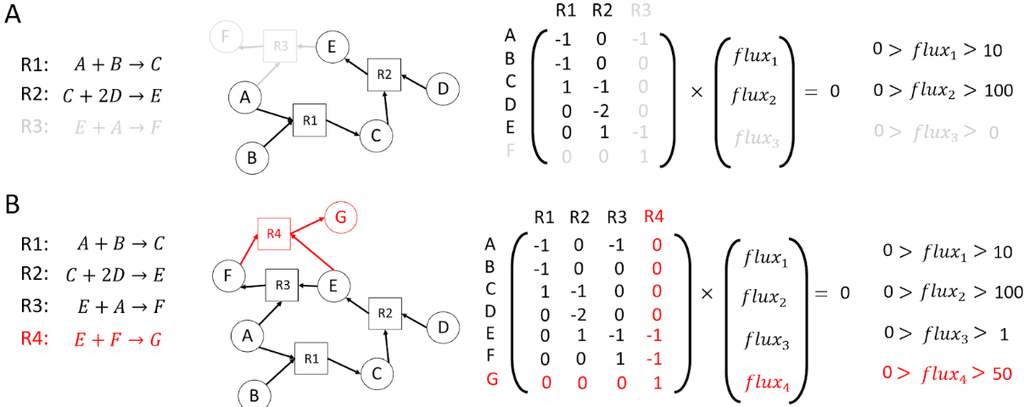

**Figure 4: Numerical and visual representation of genetic modifications in a metabolic network.** (A) Knocking-out a gene encoding an enzyme can be represented as the removal of an equation as well as by the removal of a box and the edges going toward this box. Numerically, it corresponds to the removal of a column in the stoichiometric matrix and is also equivalent to setting both the upper and lower flux bounds to 0. (B) Addition of an enzyme can be represented by the addition of an equation, as well as by the addition of a box and edges going toward this box. It also corresponds to adding a column in the stoichiometric matrix and defining bounds for the reaction catalyzed by this enzyme. Moreover, if the introduction of the new enzyme leads to the addition of a new metabolite, a circle is added to the graph and a row is added to the matrix.

### Deleting reactions

By deleting reactions in the metabolic model and running FBA, we can predict the lethality of these deletions on the strain. Let's try with an example deletion in *S.elongatus*. In this organism, the Ribulose-1,5-bisphosphate carboxylase/oxygenase (Rubisco) is the enzyme that catalyzes the first major step of carbon fixation, before it is subsequently converted to feed biomass components. Thus, we expect the knock-out of this reaction to be lethal. We can check this using the knock_out() function.

```python
# We create a copy of the model
model_deletion = model_PCC7942.copy()
# We knock-out the reaction performed by the Rubisco based on the reaction ID
model_deletion.reactions.get_by_id('RBPCcx').knock_out()
# We calculate the maximum biomass flux using FBA
solution = model_deletion.optimize()
# We print the flux through the biomass reaction
print(f"Growth after KO: {solution.objective_value}")
```

```
Growth after KO: 1.7488764123831685e-16
```

As expected, when knocking out the reaction carried out by the Rubisco, the flux through the biomass reaction is 0. This deletion is not viable.

We just showed how to perform deletions by knocking out reactions. Another, way of knocking out a reaction is to delete the genes encoding the enzymes responsible for these reactions. These can be accessed by looking for the Gene-Protein-Reaction (GPR) number for the reaction we wish to knock-out.

```python
# We look for the GPR of the reaction carried out by the Rubisco
reaction = model_PCC7942.reactions.get_by_id('RBPCcx')
print(reaction.gene_reaction_rule)
```

```
SYNPCC7942_RS07295 and SYNPCC7942_RS07300 and SYNPCC7942_RS07280 and SYNPCC7942_RS07270 and SYNPCC7942_RS07275 and SYNPCC7942_RS01450 and SYNPCC7942_RS01445 and SYNPCC7942_RS07285 and SYNPCC7942_RS07290
```

From these gene ID we can then decide to knock-out one, several or all of them. Note how the genes IDs for the Rubisco are separated by "AND". This indicates that in the metabolic model, each of these genes are required for the reactions "RBPCcx" to happen. Knocking-out only one of these will result in lethality. Let's give it a try.

```python
# We create a copy of the model
model_deletion = model_PCC7942.copy()
# We knock-out the reaction performed by the Rubisco based on the gene ID
model_deletion.genes.get_by_id('SYNPCC7942_RS07295').knock_out()
# We calculate the maximum biomass flux using FBA
solution = model_deletion.optimize()
# We print the flux through the biomass reaction
print(f"Growth after KO: {solution.objective_value}")
```

```
Growth after KO: 0.0
```

Note that deleting a reaction based on this reaction's ID will only knock-out this reaction, whereas knocking out a reaction using the ID of a gene taken from the GPR of this reaction will affect all other reactions that have this ID in their GPR.

### Adding reactions

In a metabolic model, we are free to introduce new reactions and compounds. This can be useful when one wants to assess the feasibility of producing a compound of interest in a given strain. Let's try to implement the export of a compound out of the cell. For example, we will create a transport reaction for the excretion of succinate.

```python
model_PCC7942 = load_model("iJB785")
```

```python
# Make a copy of the model to work on
model_addition = model_PCC7942.copy()

# We retrieve cytosolic succinate from the model
succ_c = model_addition.metabolites.get_by_id('succ_c')

# First we create the extracellular version of succinate
succ_e = Metabolite(
        id='succ_e',
        name='Succinate (extracellular)',
        formula='C4H4O4',
        charge=-2,
        compartment='e')
# We add extracellular succinate to the model
model_addition.add_metabolites([succ_e])


# Then we create the transport reaction
succ_trans = Reaction('SUCC_export')
succ_trans.name = 'Succinate Transport (cytosol to extracellular)'
succ_trans.lower_bound = 0   # A lower bound of 0 corresponds to an irreversible reaction
succ_trans.upper_bound = 1000
# We add the metabolites to the reaction by setting stoichiometric coefficients
succ_trans.add_metabolites({
    succ_c: -1,
    succ_e: 1
})
model_addition.add_reactions([succ_trans])
```

Now we run FBA on the model without addition of these two reactions and on the model with addition of this reaction. By accessing the information for cytosolic succinate, we can see that the export reaction we just created was absent in the original model and is now present in the model with addition.

```python
model_PCC7942.metabolites.get_by_id('succ_c')
```

| **Metabolite identifier** | succ_c |
| --- | --- |
| **Name** | Succinate |
| **Memory address** | 0x28741c2aa50 |
| **Formula** | C4H4O4 |
| **Compartment** | c |
| **In 4 reaction(s)** | SUCDum, PROAKGOX1, ASPO5, DM_succ_c |

```python
model_addition.metabolites.get_by_id('succ_c')
```

| **Metabolite identifier** | succ_c |
| --- | --- |
| **Name** | Succinate |
| **Memory address** | 0x2873bf48b60 |
| **Formula** | C4H4O4 |
| **Compartment** | c |
| **In 5 reaction(s)** | SUCDum, SUCC_export, ASPO5, PROAKGOX1, DM_succ_c |

Additionally we can print the flux through the biomass reaction before and after adding the reaction and we can see that the addition didn't impact the growth.

```python
solution_original = model_PCC7942.optimize()
solution_addition = model_addition.optimize()
print(f"Growth before addition of succinate export: {solution_original.objective_value}")
print(f"Growth after addition of succinate export: {solution_addition.objective_value}")
```

```
Growth before addition of succinate export: 0.053902514144381845
Growth after addition of succinate export: 0.053902514144384725
```

## Storing modified models

The standard format for using and sharing metabolic model is the SBML format. Run the following chunck of code to save the modified models we created.

```python
write_sbml_model(model_deletion, "model_addition.xml") # Store the modified model of S.elongatus PCC 7942 in which we added a reaction
write_sbml_model(model_PCC7942_additionL, "model_deletion.xml") # Store the modified model of S.elongatus PCC 7942 in which we deleted a reaction
```

## References

Broddrick JT, Rubin BE, Welkie DG, Du N, Mih N, Diamond S, Lee JJ, Golden SS, Palsson BO. Unique attributes of cyanobacterial metabolism revealed by improved genome-scale metabolic modeling and essential gene analysis. Proc Natl Acad Sci U S A. 2016 Dec 20;113(51):E8344-E8353. doi: 10.1073/pnas.1613446113. Epub 2016 Dec 1. PMID: 27911809; PMCID: PMC5187688.